# Brand perception through sentiment analysis

Group Assignment: Sai Krupan Seela, Kavivanan Muthaiyan, Anup Radhakrishnan, Santosh SG

### Objective: Brand perception through Sentiment Analysis

#### Steps to achieve:

1. Establish twitter api connection through R
2. Extract tweets from Twitter feed for a brand
3. Data Cleansing
4. Corpus Creation
5. Term Document Matrix and Word Cloud
6. Correlations and HeatMaps
7. Association and Topic Modelling
8. Sentiment Analysis
9. Stream Graph

```r
rm(list=ls())
library(twitteR)
library(ROAuth)
library(dplyr)
library(stringr)
library(ggplot2)
library(httr)
library(wordcloud)
library(sentiment)
library(RCurl)
library(plyr)
library(SnowballC)
library(tm)
library(RColorBrewer)
library(topicmodels)
library(data.table)
library(stringi)
library(qdap)
library(streamgraph)
library(tidytext)
library(gridExtra)
library(beepr)
library(png)
```

#### Step 1: Establish twitter api connection through R

To establish connection to twitter API, we’ll use OAuthFactory function and twitter Application credentials. Once creating a new conncection we can save the credentials in a file and just load the credentials file whenever we need a connection to twitter instead of running all the code. In this assignment we’ve downloaded the tweets and saved in a csv file and loaded the file for analysis. Code to extract the tweets is given below with in comments, ofcourse with masked credentials.

##### Code for connecting to Twitter API

```r
# oauth_endpoint(authorize = 'https://api.twitter.com/oauth',
#                access = 'https://api.twitter.com/oauth/access_token')
#
# ##Connect to API
# ##Connection strings
# download.file(url = 'http://curl.haxx.se/ca/cacert.pem', destfile = 'cacert.pem')
# reqURL = 'https://api.twitter.com/oauth/request_token'
# accessURL = 'https://api.twitter.com/oauth/access_token'
# authURL = 'https://api.twitter.com/oauth/authorize'

##Twitter Application credentials
# consumerKey = '*************************'
# consumerSecret = '**************************************************'
# accessToken   = '**********-***************************************'
# accessTokenSecret = '**********-**********************************'
#
#
# Cred = OAuthFactory$new(consumerKey = consumerKey,
#                         consumerSecret = consumerSecret,
#                         requestURL = reqURL,
#                         accessURL = accessURL,
#                         authURL = authURL)
#
# Cred$handshake(cainfo = system.file('CurlSSL', 'cacert.pem', package = 'RCurl'))

# save(Cred, file = 'twitter_authentication.Rdata')
# load('twitter_authentication.Rdata')

##Twitter setup

# setup_twitter_oauth(consumer_key = consumerKey, consumer_secret = consumerSecret,
#                     access_token = accessToken, access_secret = accessTokenSecret)
```

#### Step 2: Extract tweets from Twitter feed for a brand

As mentioned in the first step, we already downloaded the tweets, saved in csv file. Hence code to extract the tweets is commented.

##### Extract tweets from twitter API and save to csv file.

```r
#tweets = searchTwitter(searchString = "infosys",n = 5000, lang = 'en', since = '2016-10-10', until = '2016-10-19')

# tweets.length = length(tweets)
# tweets.length
# tweets.df = ldply(tweets, function(t) t$toDataFrame())
# View(tweets.df)

#Save Tweets to csv file
# write.csv(tweets.df, 'infosys.csv')
```

##### Read tweets from csv

```r
# Read data from csv
tweets.df = read.csv("infosys.csv", header = TRUE, stringsAsFactors=FALSE, encoding = "ANSII")

# Convert data to data frame
tweets.df = as.data.frame(tweets.df)

# Convert ID to character which is in sceintific notation.
tweets.df$id = as.character(tweets.df$id)

# Convert Created to Date which is in date time format.
tweets.df$created = as.Date(tweets.df$created)

#Check structure of data frame
str(tweets.df)
```

```
## 'data.frame':    5000 obs. of  17 variables:
##  $ X            : int  1 2 3 4 5 6 7 8 9 10 ...
##  $ text         : chr  "AMI Business Survey: With business slowdown, IT giants like TCS, Infosys face need to keep https://t.co/aiVKA4hmyL" "Infosys may see slowdown in growth https://t.co/HCW9YOoE31 https://t.co/hoiBRoCCBd" "RT @OneAvnish: Robots for Procurement Functions. @nitesh_banga conducti…
##  $ favorited    : logi  FALSE FALSE FALSE FALSE FALSE FALSE ...
##  $ favoriteCount: int  0 0 0 0 0 0 1 0 0 0 ...
##  $ replyToSN    : chr  NA NA NA NA ...
##  $ created      : Date, format: "2016-10-18" "2016-10-18" ...
##  $ truncated    : logi  FALSE FALSE FALSE FALSE FALSE FALSE ...
##  $ replyToSID   : num  NA NA NA NA NA NA NA NA NA NA ...
##  $ id           : chr  "788529159479947264" "788526716893270016" "788523855136423936" "788523842784288768" ...
##  $ replyToUID   : num  NA NA NA NA NA NA NA NA NA NA ...
##  $ statusSource : chr  "<a href=\"http://www.google.com/\" rel=\"nofollow\">Google</a>" "<a href=\"http://publicize.wp.com/\" rel=\"nofollow\">WordPress.com</a>" "<a href=\"http://twitter.com/#!/download/ipad\" rel=\"nofollow\">Twitter for iPad</a>" "<a href=\"http://twitter.com/#!/download/ipad\…
##  $ screenName   : chr  "ossbss_ami_ucc" "PProBiz" "Ncherukupalli" "Ncherukupalli" ...
##  $ retweetCount : int  0 0 5 3 0 0 1 51 51 51 ...
##  $ isRetweet    : logi  FALSE FALSE TRUE TRUE FALSE FALSE ...
##  $ retweeted    : logi  FALSE FALSE FALSE FALSE FALSE FALSE ...
##  $ longitude    : num  NA NA NA NA NA NA NA NA NA NA ...
##  $ latitude     : num  NA NA NA NA NA NA NA NA NA NA ...
```

```r
#Check Minimum Tweeted Date and Maximum Tweeted Date
tweets.df %>%  group_by(1) %>%  summarise(max = max(created), min = min(created))
```

```
##          max        min
## 1 2016-10-18 2016-10-14
```

#### Step 3: Data Cleansing

Once extraction of tweets is done, we come to the important step of data Cleansing and Corpus creation. This step is critical as it can make or break your data on which your modelling depends. Improper data cleansing can provide incorrect insights in sentimental analysis.

Here is the order of cleaning tweets text. 1. First step in this is to remove URLS as it might get difficult to remove URLs after removing punctuation, numbers etc, as it disturbs the url text which prevents removing URLS. 2. We’ll remove strings between “<” and “>”. This is to remove smileys and other encoded text. 3. Remove retweet entities like @RT etc.. 4. Remove quotes and apostrophe like India’s, ‘Guidance’ etc.. 5. Remove @people text. Ex: @Infosys 6. Remove punctuation. This removes basic english punctuation. 7. Remove single letters like ‘s’, ‘a’ 8. Remove unnecessary spaces. 9. Remove leading and trailing white spaces.

Once tweets text is cleaned, we’ll save the data frame in to a csv file as a backup for cleaned data.

```r
# Taking backup in to new column before text cleansing
tweets.df$OriginalText = tweets.df$text

# Remove URLs
tweets.df$text = gsub("http[^[:space:]]*", "",tweets.df$text)

# Remove character string between < > to remove smiley and other encodings
tweets.df$text <- genX(tweets.df$text, " <", ">")

# Remove retweet entities
tweets.df$text = gsub("(RT|via)((?:\\b\\W*@\\w+)+)"," ",tweets.df$text)

# Remove quotes
tweets.df$text = gsub("'s|'s|[...]", "", tweets.df$text)

# Remove at people
tweets.df$text = gsub("@\\w+", " ", tweets.df$text)
# Remove punctuation
tweets.df$text = gsub("[[:punct:]]", " ", tweets.df$text)

# Remove single letters.
tweets.df$text = gsub(" *\\b[[:alpha:]]{1}\\b *", "", tweets.df$text)

# Remove unnecessary spaces
tweets.df$text = gsub("[ \t]{2,}", " ", tweets.df$text)

# Remove leading and trailing whitespaces
tweets.df$text = gsub("^\\s+|\\s+$", "", tweets.df$text)

#str(tweets.df)

write.csv(tweets.df,"infosys_Sql.csv")
```

Next step is to create corpus creation. But brfore proceeding to corpus creation we will see if there are any duplicate tweets by users and check for spam tweets.

We’ll see how many tweets are repeated and what kind of tweets are duplicated. ##### Check for duplicate tweets.

```r
tweets.text = data.frame(tweets.df$text, tweets.df$screenName)
grouped_data <- aggregate(tweets.text, by=list(tweets.df$text, tweets.df$screenName), FUN=length);
colnames(grouped_data) = c("Text","ScreenName","TweetCount_1","Tweet_Count_2")
grouped_data = arrange(grouped_data, desc(TweetCount_1))
head(subset(grouped_data, grouped_data$TweetCount_1 > 1))
```

```
##                                                                                                 Text
## 1           AMI Business Survey With business slowdown IT giants like TCS Infosys face need to keep
## 2                      AMI Business Survey Infosys Tata Consultancy Services results signaldownward
## 3                   AMI Business Survey Infosys Q2 net up 61 cuts rev outlook for 2nd time in 3mths
## 4 Technology Infosys cuts revenue outlook again as clients slow spending ahead of US election Brexit
## 5                   Infosys Q2 revenue up but cuts full year target Economic Times news india topsto
## 6            AMI Business Survey Infosys Tata Consultancy Services results signaldownward inflexion
##       ScreenName TweetCount_1 Tweet_Count_2
## 1 ossbss_ami_ucc           34            34
## 2 ossbss_ami_ucc           18            18
## 3 ossbss_ami_ucc            9             9
## 4    ii_newsdesk            6             6
## 5    being_malik            5             5
## 6 ossbss_ami_ucc            5             5
```

We can see there are such duplicate tweets by same ScreenName. We don’t want to include such tweets as it affects the strength of sentiment.

For example, First tweet by “ossbss_ami_ucc” is repeated 34 times. If the tweet by that screen name has any keyword affecting the sentiment, it strengthens the senitment as the same keyword is repeated 34 times. But ideally it should be considered only once so that the sentiment won’t be affected.

To solve this duplicate tweets problem, we will consider unique tweets in the combination of Text and ScreenName.

```r
# Extract unique tweets in combination of Text and ScreenName
tweets.df = data.table(tweets.df)
tweets.df = unique(tweets.df, by = c("text","screenName"), fromLast=TRUE)

nrow(tweets.df)
```

```
## [1] 4757
```

We can see the count reduced from 5000 tweets after extracting unique tweets.

In the next step, we’ll check for spam tweets. Spam tweets also affect the sentiment adding inappropriate strength. Generally these spam tweets be in large numbers. As it’s not possible to go through all tweets, we’ll check tweets with highest frequency and check for any spam. Along with that, we also check for spam keywords and analyze the tweets for spam.

##### Check for spam tweets.

```r
tweets.text = data.frame(tweets.df$text)
grouped_data <- aggregate(tweets.text, by=list(tweets.df$text), FUN=length);
colnames(grouped_data) = c("Text","TweetCount")
grouped_data = arrange(grouped_data, desc(TweetCount))
tweets.text.duplicate = subset(grouped_data, grouped_data$TweetCount > 1)

head(tweets.text.duplicate, n = 20)
```

```
##                                                                                                                               Text
## 1                                                        Infosys TCS numbers reflect everything that is wrong with India IT sector
## 2                                                       IT pain TCS struggles to repeat past success Infosys stares at lower score
## 3                                                   Infosys cuts annual revenue target for second time as US election Brexit weigh
## 4                                          Infosys cuts revenue outlook again as clients slow spending ahead of US election Brexit
## 5                             Infosys Reports 61 Profit Rise but Cuts Outlook Infosys reported61 rise in fiscal second quarter net
## 6                                                                     Infosys revises salaries of CFO COO and other key executives
## 7                                                                     Nifty ends near 8 600 RIL up 2 Infosys dips post Q2 earnings
## 8                                                        Not the endgame for Infosys TCS Why it too early for an obit on Indian IT
## 9                                                                       Infosys cuts guidance to 8 9 despite better Q2 performance
## 10                                                                               Infosys Ltd stock update as on 4 00PM 18 Oct 2016
## 11                                                                               Infosys Ltd stock update as on 9 59AM 14 Oct 2016
## 12                                                             Infosys cuts guidance to 8 9 per cent despite better Q2 performance
## 13                                                                                       Infosys revises pay for senior executives
## 14                                                       Infosys revises salary of CFO Pravin Rao likely to touch Rs 8 cr annually
```

[output cut: 27 more lines]

```r
tweets.text.duplicate[grep("stock|retweet|follow|update",tweets.text.duplicate$Text),]
```

```
##                                                                                                           Text
## 10                                                           Infosys Ltd stock update as on 4 00PM 18 Oct 2016
## 11                                                           Infosys Ltd stock update as on 9 59AM 14 Oct 2016
## 28   follow rt retweet Infosys Revises Pay Packages Of Key Executives The Bengaluru based firm has also induct
## 49                                                       Hefty pay hike stocks for Infosys managers executives
## 117        MOST ACTIVE STOCKS ICICI Bank SBI Infosys and Axis Bank are top active stocks in value terms on NSE
## 131  follow and retweet Infosys Revises Pay Packages Of Key Executives The Bengaluru based firm ha followtrick
## 161 follow and retweet Infosys Revises Pay Packages Of Key Executives The Bengaluru based firm has also induct
## 166   Hefty pay hike stocks for Infosys managers executives Each senior executive will also be granted 245 750
## 229                                                 Daily updated synthesis about PNRA at KenBoneFacts Infosys
## 330                                        TCS gains 2 Infosys falls 5 but which IT co fared well in Q2 stocks
## 382                         disappointing annual outlook for Infosys INFY has stock amp options volume surging
## 395              Eligible for ESOPs Read this All you wanted to know about restricted stock unit Business Line
## 417                                       Hefty pay hike stocks for Infosys managers executives Economic Times
## 418      Hefty pay hike stocks for Infosys managers executives Software major Infosys on Friday announcedhefty
```

[output cut: 17 more lines]

Looks good. We didn’t find any spam tweets atleast with high frequency which could affect the sentiment. So we’ll continue with the next step of Corpus creation. We have 4757 tweets for corpus creation. It takes lot of time to create this huge corpus of size approx 17 MB. We thought of picking a random sample of 2000 but proceeded with entire data extracted. We’ll proceed with the next step of Corpus creation.

#### Step 4: Corpus Creation

Generally, first step in corpus creation is to convert text in to lower case. We did not want to lose Entity words like US(United States), IT(Information Technology) and other related keywords. If we convert to lower case, those will be lost in one of the corpus transformation steps like stemming, removing stop words etc.

Apart from it, we almost done all basic corpus transformation steps required. 1. Remove punctuations 2. Remove Single Letter words 3. Remove stop words 4. Remove whitespaces 4. Stemming and correction/completion of words after stemming using a copy of corpus as dictionary. Generally this step of correcting the stemmed text takes long time. So it’s better to save a copy of this corpus after correction before proceeding with next steps so that you have a backup incase of any issues and it saves time

```r
#tweets.subset = tweets.df[sample(1:length(tweets.df$text),2000, replace = FALSE)]
#str(tweets.subset)
tweets.text = tweets.df$text

# Create document corpus with tweet text
myCorpus<- Corpus(VectorSource(tweets.text))

## Converting to lower
#myCorpus = tm_map(myCorpus, content_transformer(tolower))

##Remove punctuations
myCorpus = tm_map(myCorpus, removePunctuation)

# removeNumPunct <- function(x) gsub("[^[:alpha:][:space:]]*", "", x)
# myCorpus <- tm_map(myCorpus, content_transformer(removeNumPunct))

# Remove Single letter words
removeSingle <- function(x) gsub(" . ", " ", x)
myCorpus <- tm_map(myCorpus, content_transformer(removeSingle))

##Remove Stopwords
myCorpus = tm_map(myCorpus, removeWords, c(stopwords("english"),c('The', 'Rs', 'amp', 'In', 'it', 'will')))

#Check for stopwords
#myCorpusTidy = tidy(myCorpus)
#grep("\\bs\\b",myCorpusTidy$text,value=TRUE)

##Remove whitespaces
myCorpus = tm_map(myCorpus, stripWhitespace)

# Keep a copy of "myCorpus" for stem completion later
myCorpusCopy<- myCorpus

# Stem words in the corpus
myCorpus<-tm_map(myCorpus, stemDocument)

# Function to correct/complete the text after stemming
stemCompletion2 <- function(x,dictionary) {
  x <- unlist(strsplit(as.character(x)," "))
  x <- x[x !=""]
  x <- stemCompletion(x, dictionary = dictionary)
  x <- paste(x, sep="", collapse=" ")
  PlainTextDocument(stripWhitespace(x))
}

# Correction of stemmed words using backup corpus as dictionary.
myCorpus <- lapply(myCorpus, stemCompletion2, dictionary=myCorpusCopy)
beep(3)

# Keeping copy of Corpus after stemming
myCorpusAfterStemComplete = myCorpus

# myCorpus = myCorpusAfterStemComplete
myCorpus <- Corpus(VectorSource(myCorpus))

#Check for stopwords
#myCorpusTidy = tidy(myCorpus)
```

#### Step 5: Term Document Matrix and Word Cloud

With corpus created, we’ll move on to Term Document Matrix creation and create a Word Cloud. After observing the frequency of each word, we chose 150 as the minimum frequency to plot the word frequency plot.

To create word cloud, we chose 50 as minimum word frequency. But R gives a boring word cloud. To make it attractive, we saved the word and frequencies in csv file and created a word cloud in the form of twitter bird using online wordcloud creater. We’ve plotted both the versions.

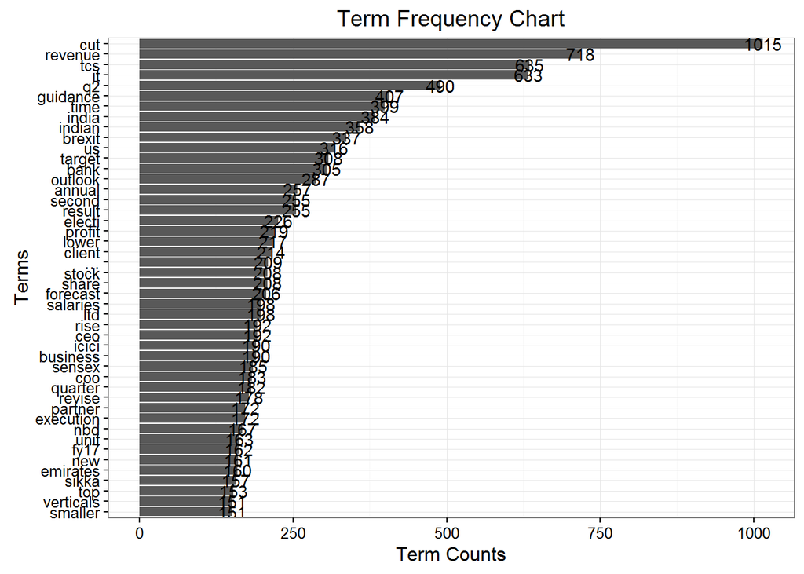

```r
# Creating TermDocumentMatrix
tdm <- TermDocumentMatrix(myCorpus, control= list(wordLengths= c(1, Inf)))
# tdm

#####Find the terms used most frequently
freq.terms <- findFreqTerms(tdm, lowfreq = 50)
term.freq <- rowSums(as.matrix(tdm))
term.freq <- subset(term.freq, term.freq > 150)
df <- data.frame(term = names(term.freq), freq= term.freq)


# plotting the graph of frequent terms
ggplot(df, aes(reorder(term, freq),freq)) + theme_bw() + geom_bar(stat = "identity")  + coord_flip() +labs(list(title="Term Frequency Chart", x="Terms", y="Term Counts")) + geom_text(aes(label=freq))
```

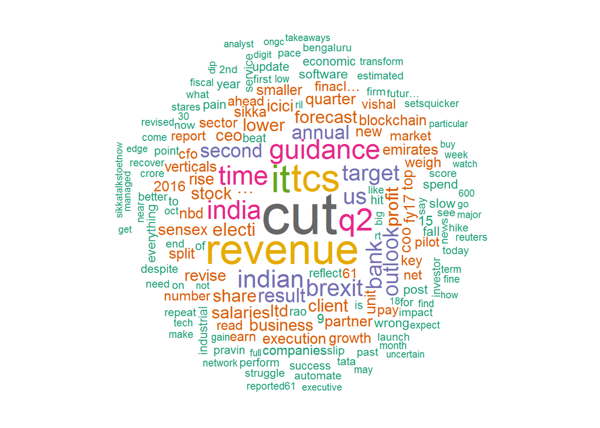

```r
# calculate the frequency of words and sort it by frequency and setting up the Wordcloud

word.freq <-sort(rowSums(as.matrix(tdm)), decreasing= TRUE)
write.csv(data.frame(word.freq),"wordFreq.csv")
pal<- brewer.pal(8, "Dark2")
wordcloud(words = names(word.freq), freq = word.freq, min.freq = 50, random.order = F, colors = pal, max.words = 2000)
```

[figure not shown]

```r
img <- readPNG("WordCloud.png", native = FALSE)
rimg <- as.raster(img) # raster multilayer object
r <- nrow(rimg) / ncol(rimg) # image ratio
plot.new()
rasterImage(rimg, 0, 0, 1, r)
```

#### Step 6: Correlations and HeatMaps

After looking at the word cloud we can see words like cut, revenue, tcs, us, it, brexit, ceo, result, coo, cfo, target, client, sikka, guidance, share, forecast have higher strength and hence highlighted in the wordcloud.

We’ll take these words and proceed next to identify correlations between them and other words in the tweets.

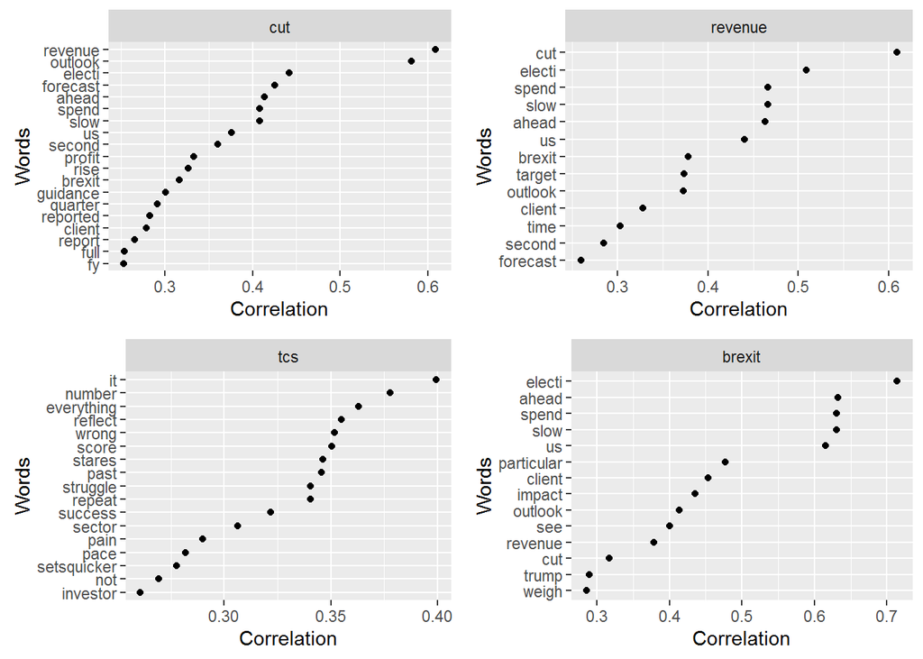

```r
#Function to create Word Correlation using the corpus.
fn_getWordCorr = function(Corpus, cor_word, cor_strength)
{
  WordCorr = apply_as_df(Corpus[1:4000], word_cor, word = cor_word, r = cor_strength)
}

fn_plotWordCorr = function(wordCorr)
{
  plot(wordCorr)
}

fn_qheatWordCorr = function(wordCorr)
{
  qheat(vect2df(wordCorr[[1]], "word", "cor"), values=TRUE, high="red", digits=2, order.by ="cor", plot = FALSE) + coord_flip()
}

corrWords = c('cut', 'revenue', 'tcs', 'brexit')

wordCorrs = lapply(corrWords, fn_getWordCorr, cor_strength = .25, Corpus = myCorpus)

wordCorrs.plot = lapply(wordCorrs, fn_plotWordCorr)
wordCorrs.qheat = lapply(wordCorrs, fn_qheatWordCorr)

do.call("grid.arrange", c(wordCorrs.plot, ncol=2))
```

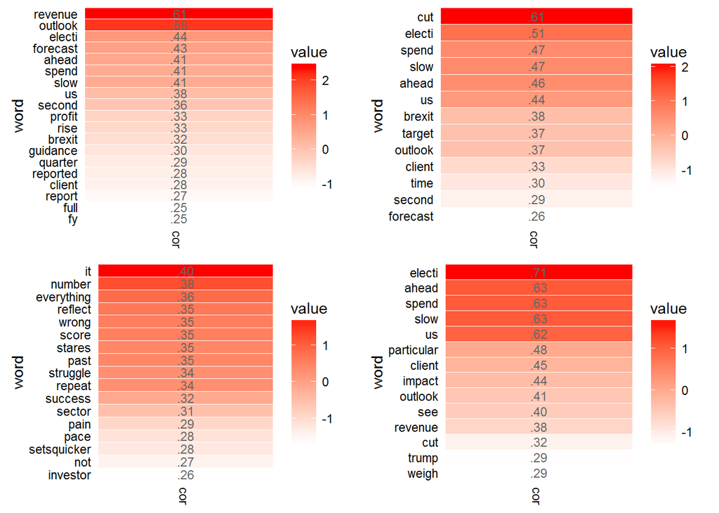

```r
do.call("grid.arrange", c(wordCorrs.qheat, ncol=2))
```

```r
# This is not an exhaustive list, we can do this for any set of words.
```

We’ll try to draw some insights on the above correlations.

First word is “cut”. We’ll see some tweets with this word.

```r
# Messages with word - cut
df <- data.frame(text=sapply(myCorpus, `[[`, "content"), stringsAsFactors=FALSE)
head(unique(df[grep("\\bcut\\b", df$text), ]), n=10)
```

```
##  [1] "Impact digit price power cut sale forecast"
##  [2] "Read Recent New Release cut revenue guidance FY17 Q2 PAT rise 495"
##  [3] " cut revenue guidance deliver related better Q2 result TCS"
##  [4] "Check vade mecum success SEM campaign inworld cut throat competition DigitalMarketing sale"
##  [5] "Earningsreports beat expect Q2 FY2017 cut full year outlook professiona"
##  [6] " cut annual revenue target second time US electi Bre Related Articles"
##  [7] " cut revenue outlook client slow spend ahead US electi Brexit"
##  [8] "TCS revenue growth dollar term disappointed Street cut guidance second time three month"
##  [9] " cut revenue outlook client slow spend ahead US electi Brexit Ltd cut"
## [10] "stockmarkettips Ltd cut fiscal year revenue growth Trgt second time three month Visit"
```

We can see these tweets are mainly on guidance cut from Infosys due to low revenue growth. We can draw the same insight from the correlation plot that terms ‘revenue’ and ‘cut’ are highly correlated.

Similar insights can be drawn from the other words.

#### Step 7: Association and Topic Modelling

Next step is to find associations with a specific kewyword in the tweets. We’ll check the association for some the words we didn’t use for Correlation.

```r
fn_wordAssociations = function(tdm, aterm)
{
  findAssocs(tdm, aterm, 0.2)
}
assocWords = c('coo', 'cfo', 'ceo', 'us')

assocWords.association = lapply(assocWords, fn_wordAssociations, tdm = tdm)

print(assocWords.association)
```

```
## [[1]]
## [[1]]$coo
##  salaries       cfo       key    pravin    revise       rao execution
##      0.73      0.69      0.52      0.50      0.46      0.45      0.41
##        ub      home announced      come     month      fine     raise
##      0.40      0.30      0.27      0.24      0.24      0.22      0.21
##
##
## [[2]]
## [[2]]$cfo
##    salaries         coo      revise         key       touch   execution
##        0.85        0.69        0.57        0.47        0.42        0.36
##          cr   announced      pravin       raise         rao        like
##        0.33        0.31        0.27        0.24        0.24        0.23
## softwaredn        hike
##        0.22        0.21
##
##
## [[3]]
## [[3]]$ceo
##            awaits         difficult sikkatalkstoetnow         transform
##              0.48              0.48              0.47              0.43
##            vishal             sikka               inc          external
##              0.38              0.34              0.30              0.23
##               see            impact
##              0.23              0.20
##
##
## [[4]]
## [[4]]$us
##        electi        brexit         weigh          slow         spend
##          0.83          0.73          0.62          0.57          0.57
##         ahead       revenue        target        annual           cut
##          0.55          0.49          0.41          0.40          0.40
##        client       outlook          time           2nd        second
##          0.38          0.36          0.34          0.30          0.28
##      election         fraud      officers           pai    something
##          0.25          0.25          0.25          0.25          0.25
##          visa            as          deal          took       reuters
##          0.25          0.24          0.24          0.24          0.23
## investigating         place
##          0.22          0.22
```

From associations we can see how words are associated in the tweets. For example, coo, cfo words are highly associated with the word ‘salaries’. This is because lot of tweets are on the recent hike in salaries of COO and CFO of Infosys and other top executives.

Topic Modelling is to extract topics discussed from the set of words using the model LDA(Latent Dirichlet allocation). We’ll extract top 5 topics discussed and top 7 words for each topic to draw insights on topic.

```r
# Topic Modelling to identify latent/hidden topics using LDA technique
dtm <- as.DocumentTermMatrix(tdm)

rowTotals <- apply(dtm , 1, sum)

NullDocs <- dtm[rowTotals==0, ]
dtm   <- dtm[rowTotals> 0, ]

if (length(NullDocs$dimnames$Docs) > 0) {
tweets.df <- tweets.df[-as.numeric(NullDocs$dimnames$Docs),]
}

lda <- LDA(dtm, k = 5) # find 5 topic
term <- terms(lda, 7) # first 7 terms of every topic
(term <- apply(term, MARGIN = 2, paste, collapse = ", "))
```

```
##                                             Topic 1
##  "cut, revenue, lower, guidance, bank, tcs, sensex"
##                                             Topic 2
##       "revenue, us, time, bank, target, profit, it"
##                                             Topic 3
##   "it, cut, brexit, salaries, tcs, revenue, annual"
##                                             Topic 4
## "tcs, revenue, india, q2, target, growth, software"
##                                             Topic 5
##       "cut, q2, indian, india, it, emirates, icici"
```

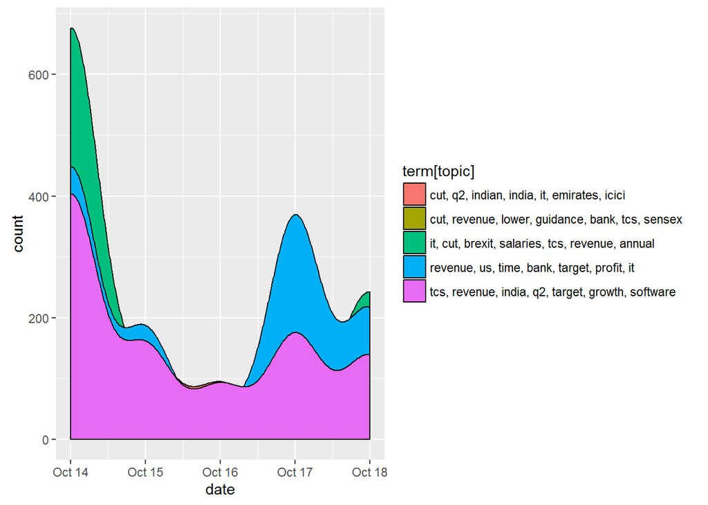

```r
topics<- topics(lda)
topics<- data.frame(date=(tweets.df$created), topic = topics)
qplot (date, ..count.., data=topics, geom ="density", fill= term[topic], position="stack")
```

```r
df <- data.frame(text=sapply(myCorpus, `[[`, "content"), stringsAsFactors=FALSE)
df = data.frame(tolower(df$text))
names(df) = c("text")

df$text = as.character(df$text)
head(unique(df[grep("\\bbank\\b | \\blower\\b | \\bicici\\b | \\bpartner\\b | \\bnbd\\ | \\bunit\\b | \\bemirates\\b", df$text), ]), n=20)
```

[output not shown]

So, these are the top 5 topics discussed in the tweets. We can just search the corpus for these words and have a look to draw more insights.

We can see topic 5 about the recent pilot carried out for using block chain network for international remittances and trade finance with ICICI Bank and Middle East - based Emirates NBD.

Topic modelling plot shows you the topic accross dates.

#### Step 8: Sentiment Analysis

Sentiment Analysis is used to analyse the positivity and negativity of the text in a corpus. We’ll detect sentiment and plot on tweets freq vs polarity, polarity vs date.

```r
# Use qdap polarity function to detect sentiment
sentiments <- polarity(tweets.df$text)

sentiments.polarity <- data.frame(sentiments$all$polarity)

sentiments.polarity[["polarity"]] <- cut(sentiments.polarity[[ "sentiments.all.polarity"]], c(-5,0.0,5), labels = c("negative","positive"))

#head(sentiments.polarity)
#is.na(sentiments.polarity$polarity)

sentiment.plot = sentiments.polarity[!is.na(sentiments.polarity$polarity)== TRUE,]

table(sentiment.plot$polarity)
```

```
##
## negative positive
##     3529     1223
```

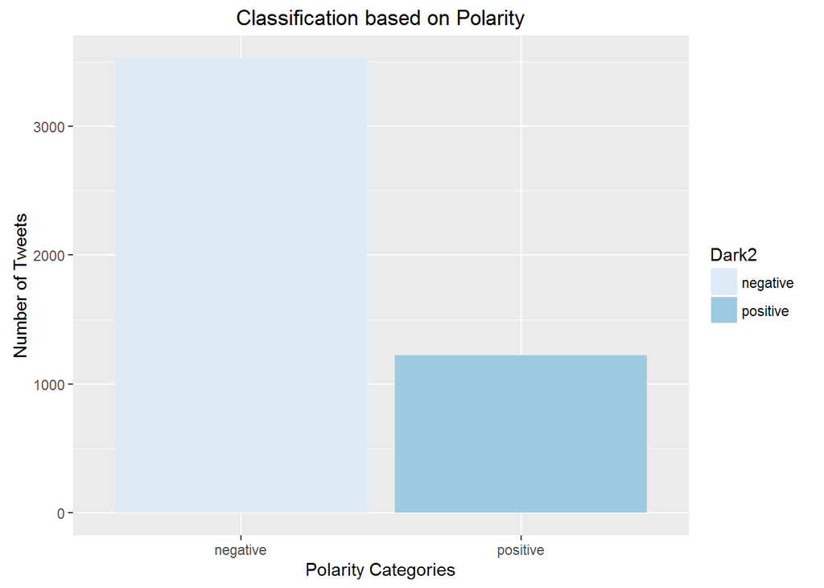

```r
#head(sentiment.plot)

ggplot(sentiment.plot, aes(x = polarity))+
  geom_bar(aes(y = ..count..,fill = polarity))+
  scale_fill_brewer((palette = "Dark2"))+
  labs(x = "Polarity Categories", y = "Number of Tweets",
       title = "Classification based on Polarity")
```

We can see classification of tweets as negative and as positive in the above result pane.

We’ll see how the sentiment played on different dates using the plot below. We scored the negative tweets as -1 and positive tweets as 1 and plotted the sum of these scores.

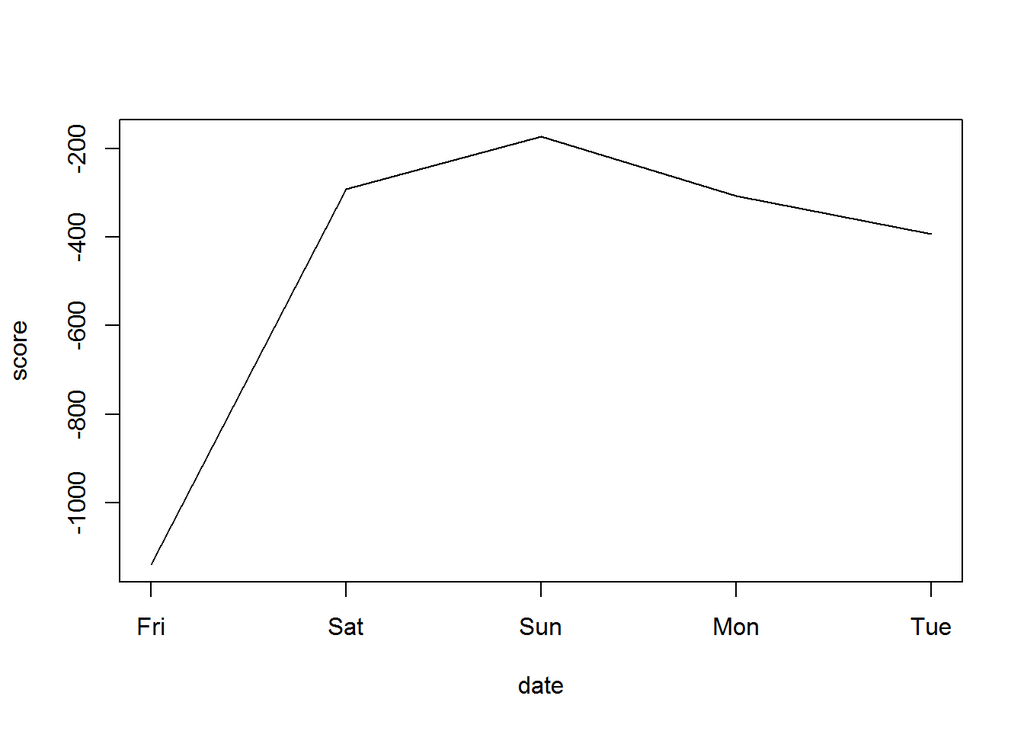

```r
# Sentiment Plot by date

sentiments.polarity$score<- 0
sentiments.polarity$score[sentiments.polarity$polarity == "positive"]<- 1
sentiments.polarity$score[sentiments.polarity$polarity == "negative"]<- -1
sentiments.polarity$date <- as.IDate(tweets.df$created)
result <- aggregate(score ~ date, data = sentiments.polarity, sum)
plot(result, type = "l")
```

We can see high negative score on Friday which is 14th October which suggest that negative tweets dominated; may be because of lower than expected results declared on the same date.

#### Step 9: Stream Graph

Final step is the stream graph an interactive graph on Polarity of tweets across different dates. In the above step we scored the tweets on polarity. Instead we can use this graph to plot area of polarity (no of tweets) vs dates.

##### StreamGraph

[interactive chart not shown]

We got the same insight as in Step 8 that negative tweets dominated highly on 14th October. Even on the succeeding days, negative tweets dominated but not as high as on the first day. No. of tweets reduced on 15th, 16th and increased on 17th and 18th.